# missSBM

Author

Marco Zanotti

Published

October 27, 2023

[figure not shown]

## Package Description

When a network is partially observed (here, NAs in the adjacency matrix rather than 1 or 0 due to missing information between node pairs), it is possible to account for the underlying process that generates those NAs. ‘missSBM’, presented in ‘Barbillon, Chiquet and Tabouy’ (2022) adjusts the popular stochastic block model from network data observed under various missing data conditions, as described in ‘Tabouy, Barbillon and Chiquet’ (2019).

The missSBM package provides the following top-level functions functions:

- `observeNetwork` a function to draw a partially observe network from an existing, fully observed network according to a variety of sampling designs
- `estimateMissSBM` a function to perform inference of SBM from a partially observed under various sampling designs.

**Warning**: these functions are based on **R6 CLASSES**, with their respective fields and methods.

## Setup

```r
library(igraph)
library(ggplot2)
library(corrplot)
library(missSBM)
library(future) # for parallel computing

set.seed(1992) # set seed for reproducibility
```

## Data

The `war` data set comes with the `missSBM` package.

```r
data("war")
```

### Belligerant Network

This data set contains a list of two networks, `belligerent` and `alliance`. Here only the first one is used, where the nodes are countries and an edge in the network `belligerent` means that the two countries have been at war at least once between years 1816 to 2007. The network `belligerent` have less nodes since countries which have not been at war at all are not considered.  
There are also possible covariates on top of the network. Here the one concerned with military power of the states is considered. The `igraph` library is used to draw the network.

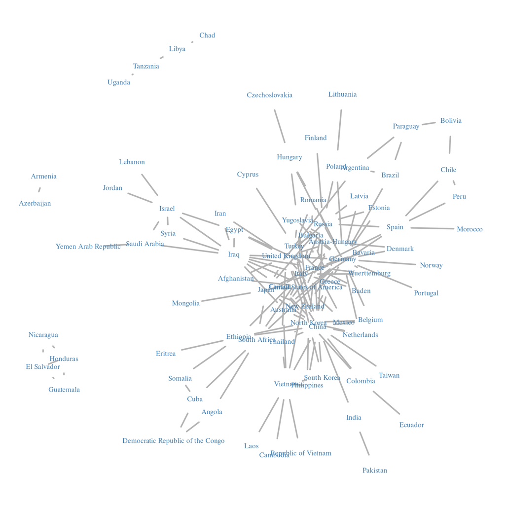

```r
par(mar = c(0, 0, 0, 0))
plot(
    war$belligerent,
    vertex.shape = "none",
    vertex.label = V(war$belligerent)$name,
    vertex.label.color = "steel blue",
    vertex.label.font = 1.5,
    vertex.label.cex = .6,
    edge.color = "gray70",
    edge.width = 2
)
```

The adjacency matrix of the network can be extracted using the function `as_adj`.

```r
belligerent_adjacency <- as_adj(war$belligerent, sparse = FALSE)
belligerent_adjacency[1:10, 1:5]
```

```
                         United States of America Canada Cuba Mexico Guatemala
United States of America                        0      0    0      1         0
Canada                                          0      0    0      0         0
Cuba                                            0      0    0      0         0
Mexico                                          1      0    0      0         0
Guatemala                                       0      0    0      0         0
Honduras                                        0      0    0      0         1
El Salvador                                     0      0    0      0         1
Nicaragua                                       0      0    0      0         0
Colombia                                        0      0    0      0         0
Ecuador                                         0      0    0      0         0
```

We can visualize the adjacency matrix again through the `corrplot` function.

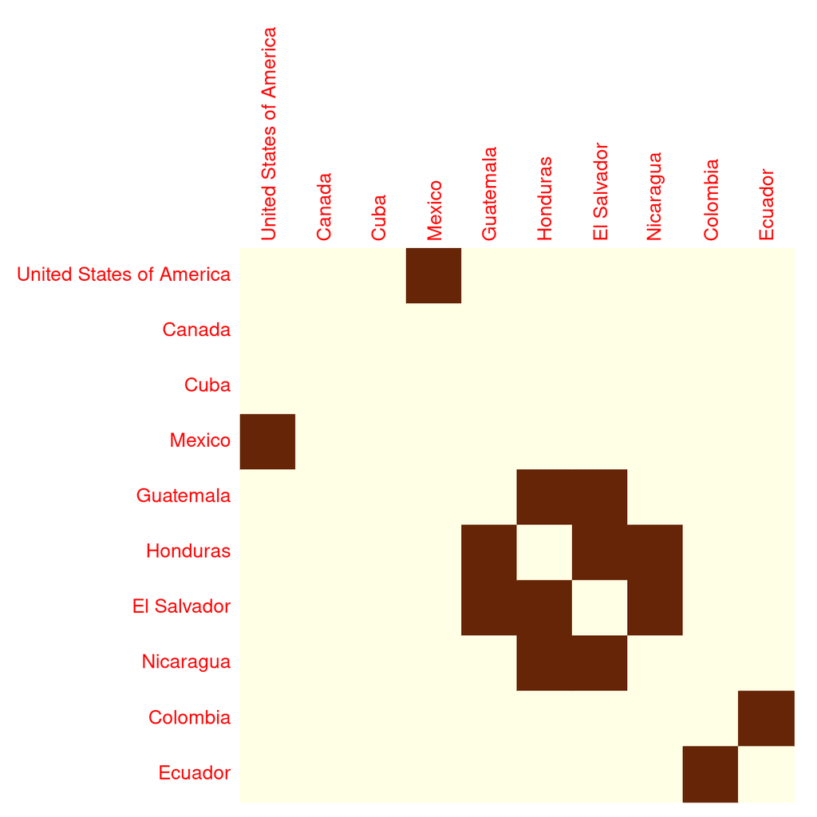

```r
corrplot(
    belligerent_adjacency[1:10, 1:10],
  is.corr = FALSE,
  method = "color",
  cl.pos = "n",
  mar = c(0,0,1,0)
)
```

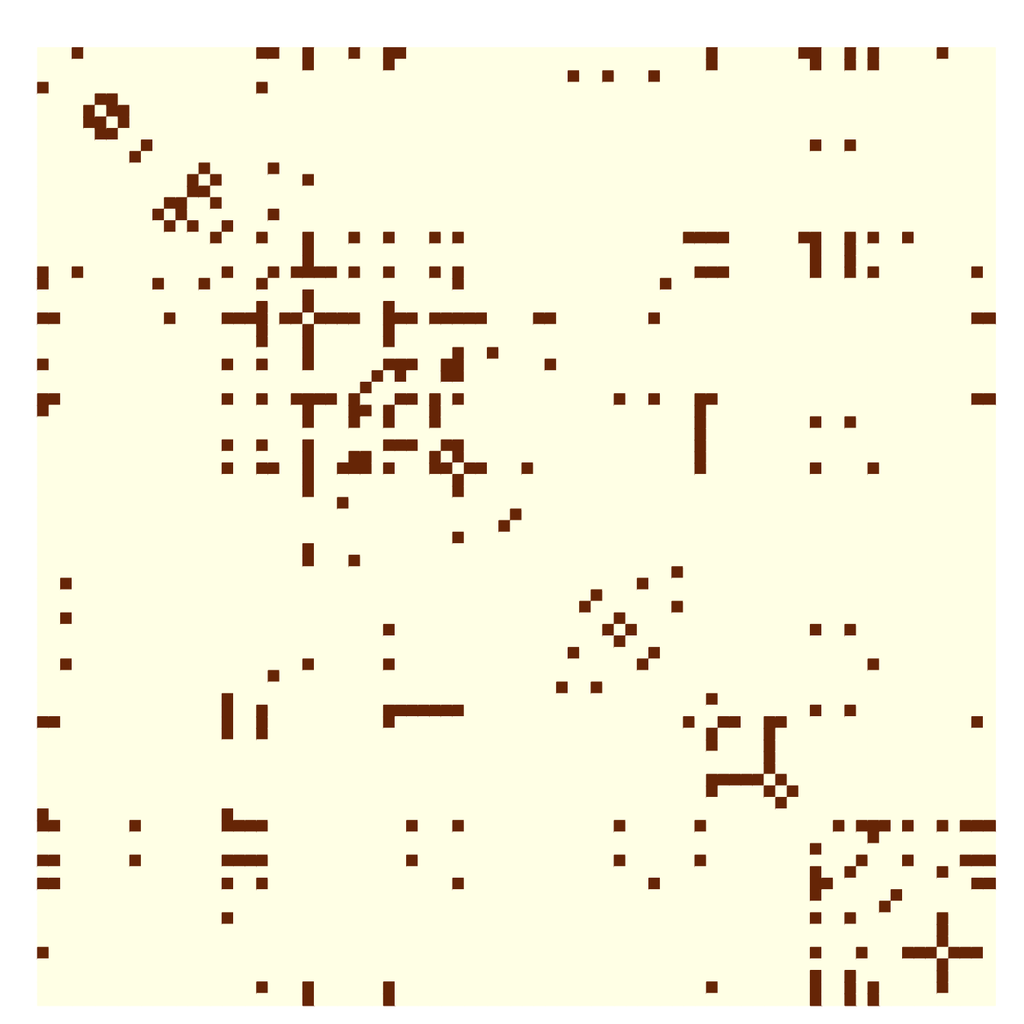

```r
corrplot(
    belligerent_adjacency,
  is.corr = FALSE,
  tl.pos = "n",
  method = "color",
  cl.pos = "n",
  mar = c(0,0,1,0)
)
```

### Generating Missing Observations

Following the authors procedure, even though the dataset is complete, it is possible to assume that some data may be missing. More specifically, the data collection may be missing for some countries in the sense that data were collected comprehensively for a subset of countries only. This implies that the sampling is **node-centered** and collects edges information accordingly (there will be a block of missing data on the diagonal of the adjacency matrix).

The function `observeNetwork` in **missSBM** allows to draw observations in an adjacency matrix according to a given network sampling design. The different sampling designs are split into two families: dyad-centered and node-centered. The sampling design has to be provided through the `sampling` argument, specifying also the parameter p, that is the probability that the node i is observed. The output is an adjacency matrix with the same dimension as the input, yet with additional NAs.

```r
set.seed(1992)
partlyObservedNet_war <- missSBM::observeNetwork(
    adjacencyMatrix = belligerent_adjacency,
    sampling = "node",
    parameters = .8
)
partlyObservedNet_war[1:10, 1:5]
```

```
                         United States of America Canada Cuba Mexico Guatemala
United States of America                        0      0    0      1         0
Canada                                          0      0   NA      0         0
Cuba                                            0     NA    0      0         0
Mexico                                          1      0    0      0         0
Guatemala                                       0      0    0      0         0
Honduras                                        0      0    0      0         1
El Salvador                                     0      0    0      0         1
Nicaragua                                       0      0    0      0         0
Colombia                                        0      0    0      0         0
Ecuador                                         0     NA   NA      0         0
```

We can visualize the adjacency matrix again through the `corrplot` function. This time some NAs are present.

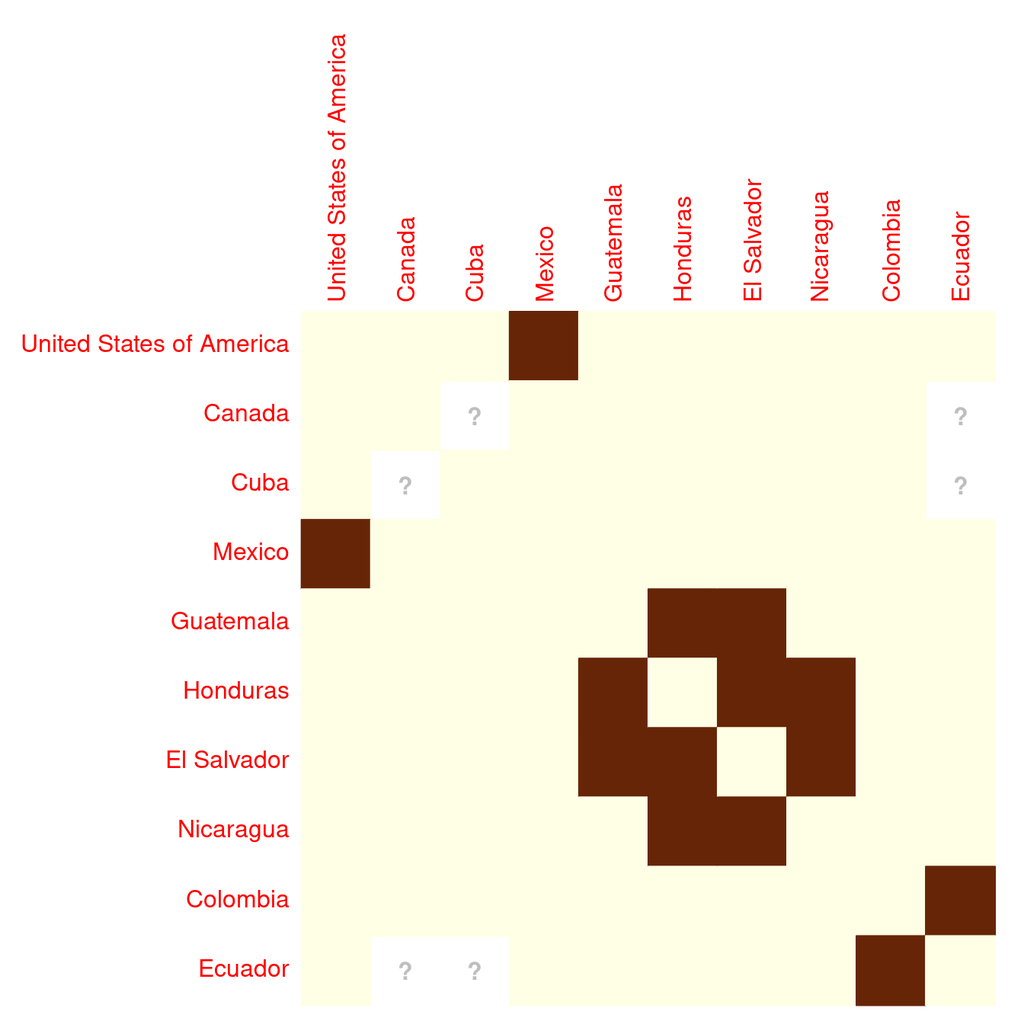

```r
corrplot(
    partlyObservedNet_war[1:10, 1:10],
  is.corr = FALSE,
  method = "color",
  cl.pos = "n",
  na.label.col = "grey",
  mar = c(0,0,1,0)
)
```

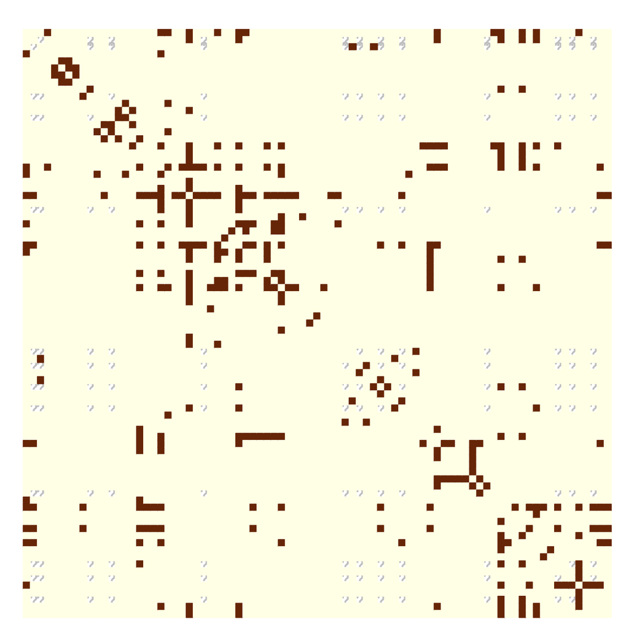

```r
corrplot(
    partlyObservedNet_war,
  is.corr = FALSE,
  tl.pos = "n",
    method = "color",
  cl.pos = "n",
  na.label.col = "grey",
  mar = c(0,0,1,0)
)
```

## Estimation

Now, the main purpose is to estimate a Stochastic Block Models (SBM) on the belligerent network. This step is performed through the function `estimateMissSBM` from the **missSBM** library. This functions provides a variational EM inference of Stochastic Block Models indexed by block number from a fully observed network, but, most importantly, from a partially observed network. By default, the function uses a forward/backward (split and merge) strategy on the clustering to avoid local minimal and get a robust Integrated Classification Likelihood Criterion (ICL), commonly used to perform model selection. This will make the choice of the number of group/block more robust.

### Estimation on Fully Observed Network

To perform the estimation one just need to specify the adjacency matrix, the number of blocks and the sampling scheme. The exploration type (forward, backward, both or none, and number of iteration can be tuned via the `control` argument). Via the argument `vBlocks` it is possible to specify the vector of number of blocks considered in the collection.

```r
vBlocks <- 1:5
collection_sbm_full <- estimateMissSBM(
    adjacencyMatrix = belligerent_adjacency,
    vBlocks = vBlocks,
    sampling = "node"
)
```

```r
collection_sbm_full
```

```
--------------------------------------------------------
COLLECTION OF 5 SBM fits
========================================================
 - Number of blocks considered: from 1 to 5
 - Best model (smaller ICL): 3
 - Fields: $models, $ICL, $vBlocks, $bestModel, $optimizationStatus
 - Method: $estimate(), $explore(), $plot()
```

On the whole collection the optimization process and the ICL for different blocks can be explored.

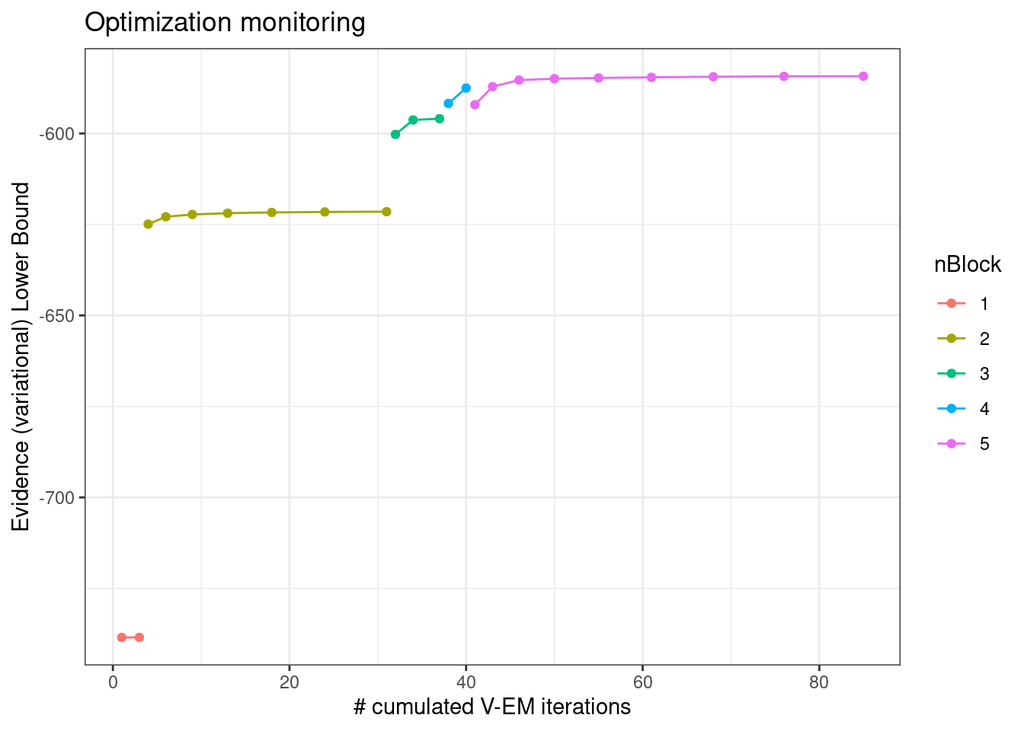

```r
plot(collection_sbm_full, "monitoring")
```

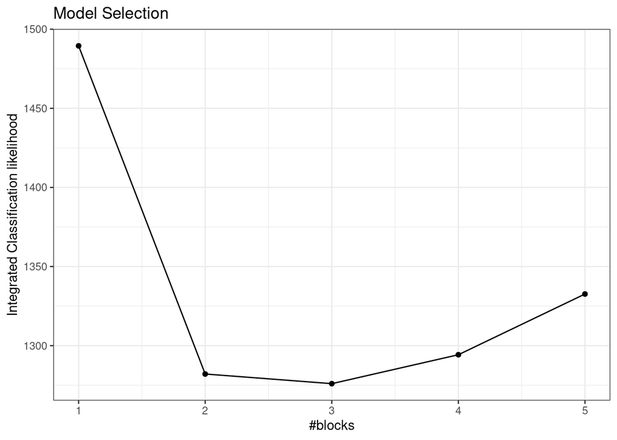

```r
plot(collection_sbm_full, "icl")
```

The best model is obtained via

```r
best_sbm_full <- collection_sbm_full$bestModel
best_sbm_full
```

```
missSBM-fit
==================================================================
Structure for storing an SBM fitted under missing data condition
==================================================================
* Useful fields (first 2 special objects themselves with methods)
  $fittedSBM (the adjusted stochastic block model)
  $fittedSampling (the estimated sampling process)
  $imputedNetwork (the adjacency matrix with imputed values)
  $monitoring, $ICL, $loglik, $vExpec, $penalty
* S3 methods
  plot, coef, fitted, predict, print
```

and the results of the estimation can be studied through various plotting methods

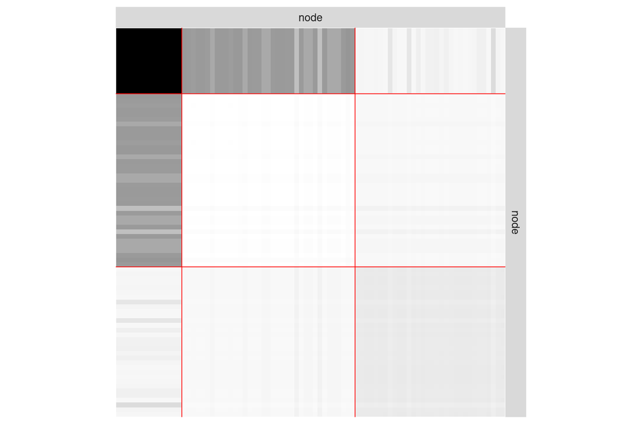

```r
plot(best_sbm_full, "expected") # to plot the expected connections
```

```r
coef(best_sbm_full, "connectivity") # to extract the mean of the communities
```

```
$mean
           [,1]         [,2]       [,3]
[1,] 0.53847981 0.1968769162 0.01551451
[2,] 0.19687692 0.0001121072 0.01259616
[3,] 0.01551451 0.0125961604 0.04078444
```

```r
fitted(best_sbm_full)[1:5, 1:5] # to obtain the fitted matrix
```

```
           [,1]         [,2]       [,3]         [,4]       [,5]
[1,] 0.53847981 0.1972320490 0.01556113 0.1946770384 0.01965087
[2,] 0.19723205 0.0005214121 0.01259605 0.0004660809 0.01231907
[3,] 0.01556113 0.0125960487 0.04076995 0.0129349320 0.04013439
[4,] 0.19467704 0.0004660809 0.01293493 0.0004180992 0.01264912
[5,] 0.01965087 0.0123190696 0.04013439 0.0126491198 0.03950682
```

```r
predict(best_sbm_full)[1:5, 1:5] # to obtain the prediction matrix
```

```
5 x 5 sparse Matrix of class "dgCMatrix"

[1,] . . . 1 .
[2,] . . . . .
[3,] . . . . .
[4,] 1 . . . .
[5,] . . . . .
```

### Estimation with Missing Data

The advantage of this package is that it allows to estimate an SBM also on the network with missing values in the very same way.

```r
vBlocks <- 1:5
collection_sbm_partly <- estimateMissSBM(
    adjacencyMatrix = partlyObservedNet_war,
    vBlocks = vBlocks,
    sampling = "node"
)
```

```r
collection_sbm_partly
```

```
--------------------------------------------------------
COLLECTION OF 5 SBM fits
========================================================
 - Number of blocks considered: from 1 to 5
 - Best model (smaller ICL): 2
 - Fields: $models, $ICL, $vBlocks, $bestModel, $optimizationStatus
 - Method: $estimate(), $explore(), $plot()
```

The best model is again obtained via

```r
best_sbm_partly <- collection_sbm_partly$bestModel
```

and the results of the estimation can be studied through various plotting methods

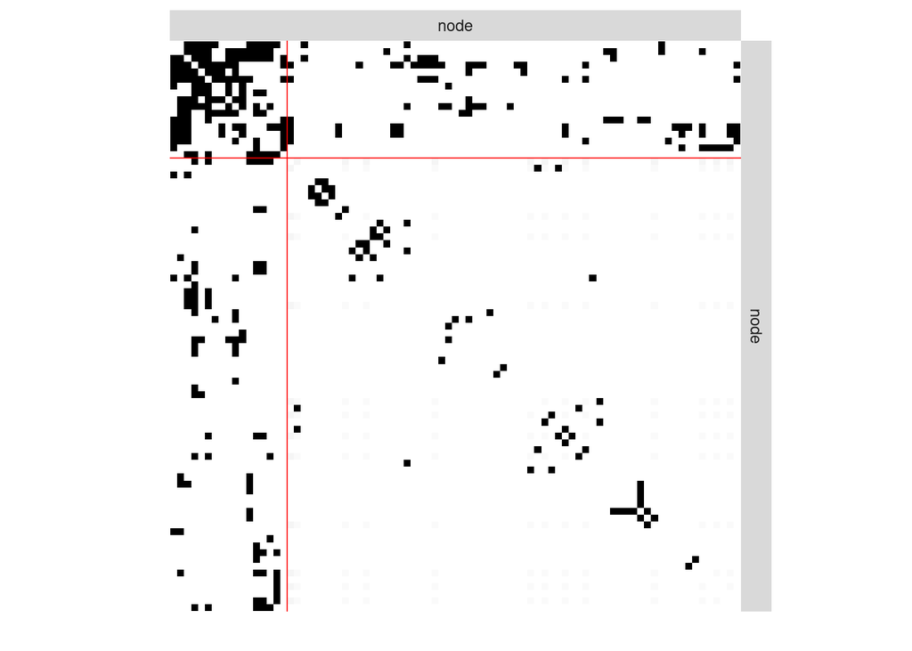

```r
plot(best_sbm_partly, "imputed") # to plot the imputed connections
```

```r
coef(best_sbm_partly, "connectivity") # to extract the mean of the communities
```

```
$mean
           [,1]       [,2]
[1,] 0.52216509 0.07705718
[2,] 0.07705718 0.01776384
```

```r
fitted(best_sbm_partly)[1:5, 1:5] # to obtain the fitted matrix
```

```
           [,1]       [,2]       [,3]       [,4]       [,5]
[1,] 0.52216389 0.26710167 0.07705870 0.07706134 0.07705767
[2,] 0.26710167 0.13872914 0.04308073 0.04308206 0.04308021
[3,] 0.07705870 0.04308073 0.01776427 0.01776462 0.01776413
[4,] 0.07706134 0.04308206 0.01776462 0.01776497 0.01776448
[5,] 0.07705767 0.04308021 0.01776413 0.01776448 0.01776399
```

```r
predict(best_sbm_partly)[1:5, 1:5] # to obtain the estimated adjacency matrix
```

```
5 x 5 sparse Matrix of class "dgCMatrix"

[1,] . .          .          1 .
[2,] . .          0.03309417 . .
[3,] . 0.03309417 .          . .
[4,] 1 .          .          . .
[5,] . .          .          . .
```

### Comparison

It would be interesting to compare the results of the estimation from the fully observed network to that with missing observations.

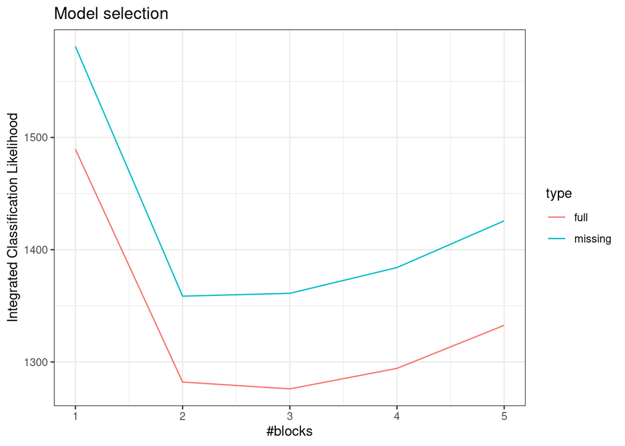

```r
rbind(
  data.frame(ICL = collection_sbm_full$ICL, nbBlocks = vBlocks, type = "full"),
  data.frame(ICL = collection_sbm_partly$ICL, nbBlocks = vBlocks, type = "missing")
) |>
  ggplot(aes(x = nbBlocks, y = ICL, group = type, color = type)) +
  labs(title = "Model selection", x = "#blocks", y = "Integrated Classification Likelihood") +
  geom_line() +
    theme_bw()
```

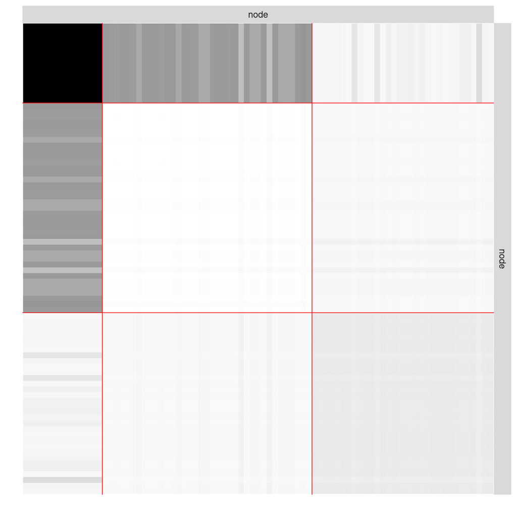

```r
plot(collection_sbm_full$bestModel, type = "expected")
```

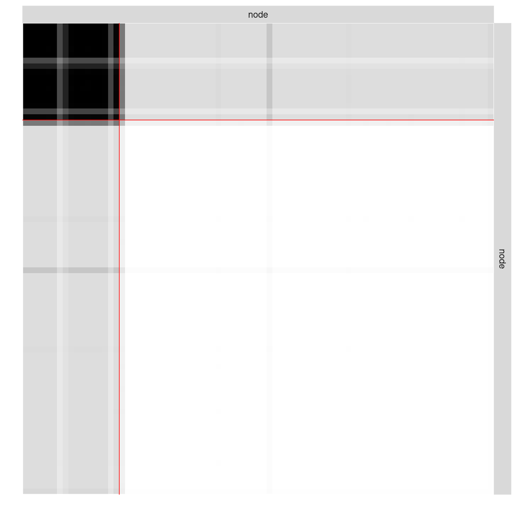

```r
plot(collection_sbm_partly$bestModel, type = "expected")
```

### Adding Covariates in the SBM

Consider a covariate reflecting the military power of the country, hence associated to the nodes. Typically, a part of the network is expected to be explained by a covariate. Including a covariate is straightforward since one just need to specify a list as the `covariates` argument.

The covariate provided as a vector is transferred on edges through an $\ell_1$ similarity: for edge $(i,j)$ the associated covariate is defined by $|x_i-x_j|$ where $x_i$ denotes the covariate for node $i$. Another similarity measure could be provided via the option `similarity`.

```r
belligerent_power <- war$belligerent$power # covariate info
vBlocks <- 1:5
collection_sbm_full_cov <- estimateMissSBM(
    belligerent_adjacency,
    vBlocks = vBlocks,
    sampling = "node",
    covariates = list(belligerent_power)
)
```

```r
collection_sbm_full_cov
```

```
--------------------------------------------------------
COLLECTION OF 5 SBM fits
========================================================
 - Number of blocks considered: from 1 to 5
 - Best model (smaller ICL): 3
 - Fields: $models, $ICL, $vBlocks, $bestModel, $optimizationStatus
 - Method: $estimate(), $explore(), $plot()
```

The estimated effect of the covariate can be explored through

```r
best_sbm_full_cov <- collection_sbm_full_cov$bestModel$fittedSBM
best_sbm_full_cov$covarEffect[1:5, 1:5] # to obtain the covariance effects
```

```
         [,1]      [,2]       [,3]       [,4]       [,5]
[1,] 0.000000 1.8015219 1.91939100 1.84231079 1.93654962
[2,] 1.801522 0.0000000 0.11786910 0.04078890 0.13502772
[3,] 1.919391 0.1178691 0.00000000 0.07708021 0.01715862
[4,] 1.842311 0.0407889 0.07708021 0.00000000 0.09423882
[5,] 1.936550 0.1350277 0.01715862 0.09423882 0.00000000
```

```r
predict(best_sbm_full_cov)[1:5, 1:5] # to obtain the estimated adjacency matrix based on covariances
```

```
           [,1]       [,2]       [,3]       [,4]       [,5]
[1,] 0.01080350 0.06207156 0.06546851 0.06123217 0.06652531
[2,] 0.06207156 0.01080596 0.01143063 0.01065119 0.01162599
[3,] 0.06546851 0.01143063 0.02189202 0.02213386 0.02226212
[4,] 0.06123217 0.01065119 0.02213386 0.01935807 0.02250796
[5,] 0.06652531 0.01162599 0.02226212 0.02250796 0.02189134
```

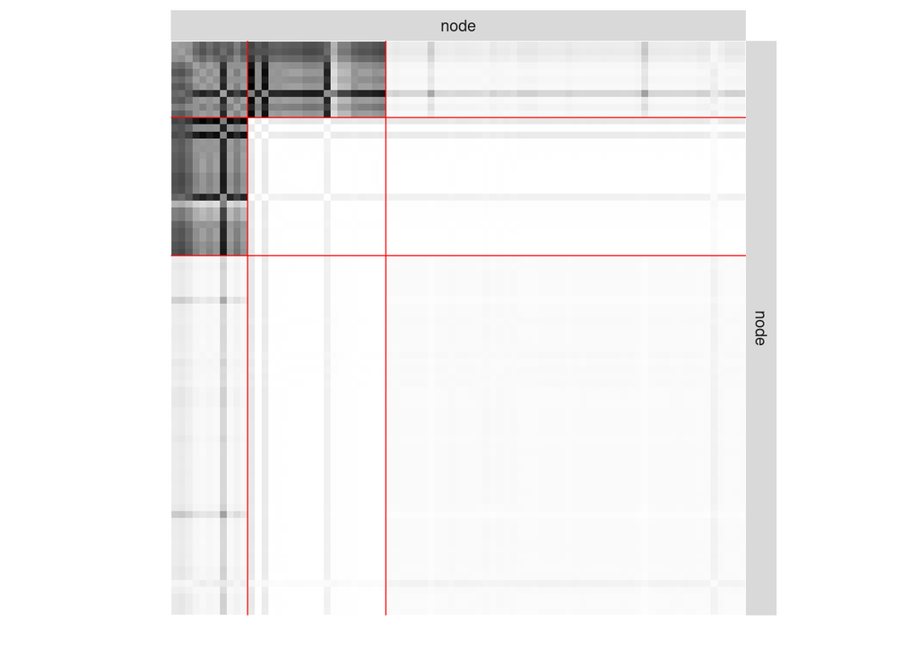

```r
plot(best_sbm_full_cov, "expected")
```